# chapter_14_solutions

1 Exercise 14.1. Growing deep trees by addition

2 Exercise 14.2. Fitting the parameters of a simple regression tree

3 Exercise 14.3. Code up a regression tree

4 Exercise 14.4. Code up a two-class classification tree

5 Exercise 14.5. Code up a multi-class classification tree

6 Exercise 14.6. Gradient boosting for regression

7 Exercise 14.7. Gradient boosting for classification

8 Exercise 14.8. Random forests

9 Exercise 14.9. Limitation of trees outside their training range

10 Exercise 14.10. Naive cross-validation

```python
# imports from custom library
import sys
sys.path.append('../')
import autograd.numpy as np
import matplotlib.pyplot as plt
import copy
datapath = '../mlrefined_datasets/nonlinear_superlearn_datasets/'

# import custom libraries
from mlrefined_libraries import nonlinear_superlearn_library as nonlib

# this is needed to compensate for %matplotlib notebook's tendancy to blow up images when plotted inline
from matplotlib import rcParams
rcParams['figure.autolayout'] = True
%matplotlib notebook
```

```
The autoreload extension is already loaded. To reload it, use:
  %reload_ext autoreload
```

# Exercise 14.1. Growing deep trees by addition

Adding $2^D-1$ one-dimensional stumps (if they do not share any split points) create $2^D-1$ unique split points. Now take the midpoint. It creates two branches, one to its left and the other two its right. So far we have accounted for $1$ split point and a depth $1$ tree. We then take the midpoint on each branch, creating a depth $2$ tree with a total of $1+2$ split points. Following this pattern we will end up using all $1+2+4+\cdots+2^k$ split points and create a depth $k+1$ tree.

All left to do is express $k$ in terms of $D$:

$$1+2+4+\cdots+2^k=2^{k+1}-1=2^{D}-1 \quad\Rightarrow\quad k=D-1$$

Therefore, adding $2^{D}-1$ stumps will create a tree of depth $k+1=D$.

# Exercise 14.2. Fitting the parameters of a simple regression tree

```python
## This code cell will not be shown in the HTML version of this notebook
# animate stump collection for a sample dataset
demo = nonlib.stump_visualizer_2d.Visualizer()
csvname = datapath + 'noisy_sin_subsample_raised_2.csv'
demo.load_data(csvname)
demo.browse_stumps()
```

[figure not shown]

# Exercise 14.3. Code up a regression tree

```python
## This code cell will not be shown in the HTML version of this notebook
# create regression tree
csvname = datapath + 'noisy_sin_subsample_2.csv'
depth = 5
tree = nonlib.recursive_tree_lib.RegressionTree.RTree(csvname,depth)

# animate growth
demo = nonlib.recursive_tree_lib.regression_animator.Visualizer(csvname)
frames = depth
demo.animate_trees(tree)
```

[figure not shown]

# Exercise 14.4. Code up a two-class classification tree

```python
## This code cell will not be shown in the HTML version of this notebook
# learn classification tree for input dataset
csvname = datapath + 'new_circle_data.csv'
depth = 7
tree = nonlib.recursive_tree_lib.ClassificationTree.RTree(csvname,depth)

# animate growth
demo = nonlib.recursive_tree_lib.classification_animator.Visualizer(csvname)
demo.animate_trees(tree)
```

[figure not shown]

# Exercise 14.5. Code up a multi-class classification tree

```python
## This code cell will not be shown in the HTML version of this notebook
# learn classification tree for input dataset
csvname = datapath + '3_layercake_data.csv'

# learn classification tree for input dataset
depth = 7
tree = nonlib.recursive_tree_lib.ClassificationTree.RTree(csvname,depth)

# animate growth
demo = nonlib.recursive_tree_lib.classification_animator.Visualizer(csvname)
demo.animate_trees(tree,pt_size = 20)
```

[figure not shown]

# Exercise 14.6. Gradient boosting for regression

```python
## This code cell will not be shown in the HTML version of this notebook
# load in dataset
csvname = datapath + 'universal_regression_samples_0.csv'
csvname = datapath + 'noisy_sin_sample.csv'

data = np.loadtxt(csvname,delimiter = ',')
x = copy.deepcopy(data[:-1,:])
y = copy.deepcopy(data[-1:,:] )

# boosting procedure
num_units = 40
runs2 = []
for j in range(num_units):
    # import the v1 library
    mylib2 = nonlib.boost_lib3.stump_booster.Setup(x,y)

    # choose normalizer
    mylib2.choose_normalizer(name = 'standard')

    # choose normalizer
    mylib2.make_train_valid_split(train_portion = 1)

    # choose cost|
    mylib2.choose_cost(name = 'least_squares')

    # choose optimizer
    mylib2.choose_optimizer('newtons_method',max_its=1)

    # run boosting
    mylib2.boost(1,verbose=False)
    mylib2.model = mylib2.models[-1]

    # add model to list
    runs2.append(copy.deepcopy(mylib2))

    # cut off output given model
    normalizer = mylib2.normalizer
    ind = np.argmin(mylib2.train_cost_vals[0])
    y_pred =  mylib2.models[-1](mylib2.normalizer(x))
    y -= y_pred

# animate the business
frames = num_units
demo2 = nonlib.boosting_regression_animators_v3.Visualizer(csvname)
demo2.animate_boosting(runs2,frames)
```

```python
## This code cell will not be shown in the HTML version of this notebook
# load in dataset
csvname = datapath + 'universal_regression_samples_0.csv'
csvname = datapath + 'noisy_sin_sample.csv'

data = np.loadtxt(csvname,delimiter = ',')
x = copy.deepcopy(data[:-1,:])
y = copy.deepcopy(data[-1:,:] )

# boosting procedure
num_units = 40
runs2 = []
for j in range(num_units):
    # import the v1 library
    mylib2 = nonlib.boost_lib3.stump_booster.Setup(x,y)

    # choose normalizer
    mylib2.choose_normalizer(name = 'standard')

    # choose normalizer
    mylib2.make_train_valid_split(train_portion = 1)

    # choose cost|
    mylib2.choose_cost(name = 'least_squares')

    # choose optimizer
    mylib2.choose_optimizer('newtons_method',max_its=1)

    # run boosting
    mylib2.boost(1,verbose=False)
    mylib2.model = mylib2.models[-1]

    # add model to list
    runs2.append(copy.deepcopy(mylib2))

    # cut off output given model
    normalizer = mylib2.normalizer
    ind = np.argmin(mylib2.train_cost_vals[0])
    y_pred =  mylib2.models[-1](mylib2.normalizer(x))
    y -= y_pred

# animate the business
frames = num_units
demo2 = nonlib.boosting_regression_animators_v3.Visualizer(csvname)
demo2.animate_boosting(runs2,frames)
```

[figure not shown]

# Exercise 14.7. Gradient boosting for classification

A signle step of Newton's method to minimize the cost function

$$g(v_L)= \frac{1}{\vert\Omega_L\vert}\sum_{p\in \Omega_L} \text{ log}\left( 1+ e^{−y_p\left(\text{model}_{m−1}\left(\mathbf{x}_p, \Theta_{m−1}\right)+v_L\right)}\right)$$

takes the form

$$g(v_L)=v_L^{0} - \frac{g'(v_L^{0})}{g''(v_L^{0})}$$

where $v_L^{0}$ is the starting point, and the first and second order derivative of $g$ at this point can be computed, respectively, as

$$g'(v_L^{0})= \frac{1}{\vert\Omega_L\vert}\sum_{p\in \Omega_L} \frac{-y_p\, e^{−y_p\left(\text{model}_{m−1}\left(\mathbf{x}_p, \Theta_{m−1}\right)+v_L^{0}\right)}}{1+ e^{−y_p\left(\text{model}_{m−1}\left(\mathbf{x}_p, \Theta_{m−1}\right)+v_L^{0}\right)}} $$

and

$$g''(v_L^{0})= \frac{1}{\vert\Omega_L\vert}\sum_{p\in \Omega_L} \frac{ e^{−y_p\left(\text{model}_{m−1}\left(\mathbf{x}_p, \Theta_{m−1}\right)+v_L^{0}\right)}}{\left(1+ e^{−y_p\left(\text{model}_{m−1}\left(\mathbf{x}_p, \Theta_{m−1}\right)+v_L^{0}\right)}\right)^2}.$$

# Exercise 14.8. Random forests

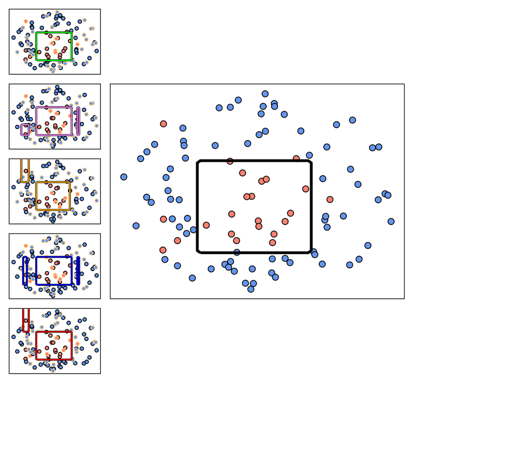

```python
## This code cell will not be shown in the HTML version of this notebook
# path to data, container for trees
datapath = '../../mlrefined_datasets/nonlinear_superlearn_datasets/'
csvname = datapath + 'new_circle_data.csv'
trees = []
num_trees = 5
depth = 7
train_portion = 0.66

for i in range(num_trees):
    tree = nonlib.recursive_tree_lib_crossval.ClassificationTree.RTree(csvname,depth,train_portion=train_portion)
    trees.append(tree)

animator = nonlib.recursive_tree_lib_crossval.classification_ensembler.Visualizer(csvname)
animator.show_runs(trees)
```

# Exercise 14.9. Limitation of trees outside their training range

Any tree, or ensemble of trees, fit to such a dataset will not allow for reliable predictions to be made *outside of the input region containing the original training data*. This is because outside of where the original training data is defined the tree predicts output *using a depth 1 tree* (a leaf in the case of a single tree). In other words, all predictiions made outside of the original region of input are *constant*.

With the student data our input is *time*, and so any tree (or ensemble of trees) will produce a *constant* prediction for all future time periods outside the region of our original input data.

# Exercise 14.10. Naive cross-validation

```python
## This code cell will not be shown in the HTML version of this notebook
# create root stump
csvname = datapath + 'noisy_sin_sample.csv'
depth = 7
tree = nonlib.recursive_tree_lib_crossval.RegressionTree.RTree(csvname,depth,train_portion = 0.66)

# animate
demo = nonlib.recursive_tree_lib_crossval.regression_animator.Visualizer(csvname)
demo.animate_trees(tree)
```

[figure not shown]